# Create your own website using Hugo on MacOS

CS

Hugo + GitHub Pages

Author

Marcobisky

Published

August 31, 2024

## Introduction and Overview

Building a generic website from scratch is a tough work. However, personal websites for blogs, a special type of website, is actually programmatic. [Hugo](https://gohugo.io) provides a convenient building templates for that. To make a new blog in Hugo, one could only just create a new folder, write a markdown file (in a specific format) and that’s it. You don’t need ANY knowledge about HTML or CSS. Well do you need to buy a domain name for everyone to see your posts? Well, GitHub Pages is a free service where you just push some contents in a repository of your own with some extremely easy command line, you created your sites of names like `yourname.github.io`.

## Tools needed

### Homebrew (Packet Manager)

We will use a packet manager called Homebrew to install Hugo. Follow the commands [here](https://brew.sh) to download Homebrew first, or you can execute:

```
/bin/bash -c "$(curl -fsSL https://raw.githubusercontent.com/Homebrew/install/HEAD/install.sh)"
```

Once downloaded, if you don’t get any error by entering this in the terminal in any folder, you installed it properly (Install testing):

```
brew --version
```

### Git (Version Control System)

You can use Homebrew to install Git:

```
brew install git
git --version # install testing
```

## Install Hugo

Run this in any folder:

```
brew install hugo
```

Install testing:

```
hugo version
```

## Run Example Theme

### Create Framework

Enter the terminal in any folder, you will be creating another main folder called `mysite` in it. Folder `mysite` will contain all the contents that are relevant to your website:

```
hugo new site mysite
cd mysite
```

Folder `mysite` should look like this:

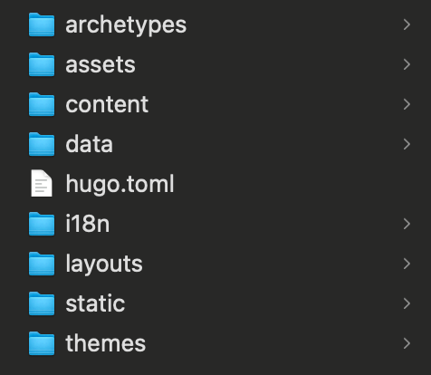

Inside `mysite` folder

with most folders in it empty. This is the framework.

### Choose Theme

The `themes` folder is empty, now we will add some code representing a theme inside it. Now choose a template [here](https://themes.gohugo.io) and downlaod its source code folder inside the `themes` folder. I use [Stack](https://github.com/CaiJimmy/hugo-theme-stack)

```
cd themes/
git clone https://github.com/CaiJimmy/hugo-theme-stack.git # Replace as needed
```

### Run Theme

Now there should be a folder inside `themes`. Now copy all the things inside a folder like `exampleSite` into the main `mysite` folder (‘’replace’’).

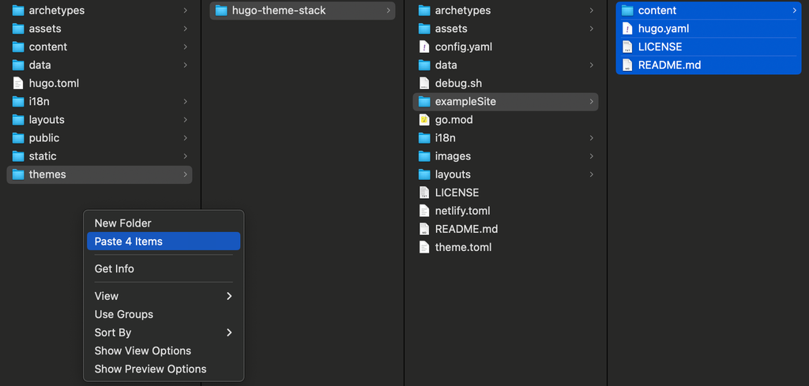

Copy the contents in `exampleSite` into `mysite`

Go to the main `mysite` folder and remove the original `hugo.tomal` file, or you can do:

```
pwd # should be in "mysite"
rm hugo.tomal
```

Then (in `mysite` folder), run:

```
hugo server -D
```

it will prompt something like:

```
Built in 865 ms
Environment: "development"
Serving pages from disk
Running in Fast Render Mode. For full rebuilds on change: hugo server --disableFastRender
Web Server is available at http://localhost:53844/ (bind address 127.0.0.1)
Press Ctrl+C to stop
```

Enter the link provided (`http://localhost:53844/`). You are done!

## Play Around

This is easy, just compare the contents in each folder and the website and modify things a little.

## Publish your website

Note the link (`http://localhost:53844/`) is private and cannot be visited on other devices. So follow these steps to publish it:

### Create GitHub Repository

Go to your GitHub page and click ‘+’ on the right upper corner, choose `New repository` and name it like this:

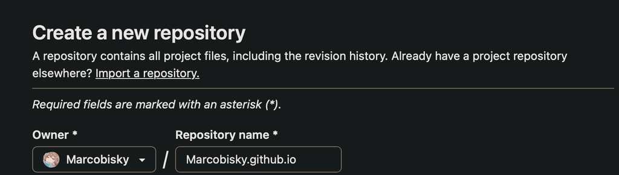

Name of your repository

i.e., `yourname.github.io`, which will be your own domain name.

### Push Contents

Run this:

```
hugo --theme=hugo-theme-stack --baseURL="https://yourname.github.io/" --buildDrafts
```

Then push the contents in your folder `public` on it by:

```
cd public
git init
git remote add origin https://github.com/yourname/yourname.github.io.git # change as needed
git add .
git commit -m "Initial commit"
git push -u origin main
```

You can access your website on `https://yourname.github.io/` within several minutes.

### Notes

After you change contents locally, the contents on `https://yourname.github.io/` will not change automatically, you will have to push it on GitHub again:

```
cd public
git add .
git commit -m "Add something new"
git push origin main
```

Also the public website will not update instantly, you will have to wait several minutes.